# Programowanie obiektowe

Wykład 7

# Dziedziczenie i polimorfizm - cd.

## Metoda `equals`

Metoda `equals()` w Javie jest używana do porównywania dwóch obiektów pod kątem równości. Standardowa implementacja `equals()` w klasie `Object` porównuje referencje, co oznacza, że dwa obiekty są uznawane za równe, jeśli wskazują na to samo miejsce w pamięci. W praktyce często chcemy porównywać obiekty na podstawie ich stanu wewnętrznego (wartości ich pól), co wymaga nadpisania metody `equals()`.

Oto zasady tworzenia dobrze zaprojektowanej metody `equals()`:

1. **Użycie słowa kluczowego `@Override`**: Wskazuje, że metoda nadpisuje metodę z klasy bazowej.
2. **Sprawdzenie, czy obiekt nie jest porównywany sam do siebie**: Jeśli tak, metoda powinna zwrócić `true`.
3. **Sprawdzenie, czy obiekt do porównania nie jest `null` i czy jest tego samego typu.**
4. **Rzutowanie obiektu do porównania na odpowiedni typ**: Po potwierdzeniu, że obiekty są tego samego typu, można bezpiecznie rzutować.
5. **Porównanie pól obiektów**: Porównaj wszystkie istotne pola. Dla pól, które są typami prymitywnymi, użyj operatorów porównania (`==`). Dla obiektów użyj `equals()`.
6. **Zwrócenie `true`, jeśli wszystkie porównania pól są równe**: W przeciwnym razie zwróć `false`.

```java
public class Person {
    private String name;
    private int age;

    public Person(String name, int age) {
        this.name = name;
        this.age = age;
    }

    @Override
    public boolean equals(Object obj) {
        // Sprawdzenie, czy obiekty są tym samym obiektem
        if (this == obj) return true;

        // Sprawdzenie, czy obj nie jest null i czy jest typu Person
        if (obj == null || getClass() != obj.getClass()) return false;

        // Rzutowanie obj do typu Person
        Person person = (Person) obj;

        // Porównanie pól
        if (age != person.age) return false;
        return name != null ? name.equals(person.name) : person.name == null;
    }

}
```

- **Kontrakt `equals()` i `hashCode()`**: Jeśli nadpisujesz `equals()`, musisz także nadpisać `hashCode()`. Kontrakt między tymi dwiema metodami mówi, że dwa obiekty uznane za równe przez `equals()` muszą zwracać tę samą wartość `hashCode()`.
- **Null-safety**: Używanie `Objects.equals()` z Java 7 i nowszych w celu uniknięcia `NullPointerException` podczas porównywania pól, które mogą być `null`.
- **Porównanie pól typu float i double**: Dla pól typu `float` użyj `Float.compare(float, float)`, a dla `double` - `Double.compare(double, double)`, aby uniknąć problemów z porównywaniem liczb zmiennoprzecinkowych.

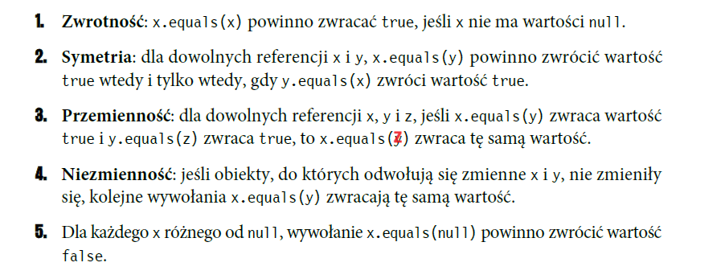

```java
class Person {
    private String name;
    private int age;

    public Person(String name, int age) {
        this.name = name;
        this.age = age;
    }

    @Override
    public boolean equals(Object obj) {
        // Sprawdzenie, czy obiekty są tym samym obiektem
        if (this == obj) return true;

        // Sprawdzenie, czy obj jest instancją Person i rzutowanie
        if (obj instanceof Person person) {
            // Porównanie pól
            if (age != person.age) return false;
            return name != null ? name.equals(person.name) : person.name == null;
        }

        return false;
    }

    // Gettery, settery, hashCode(), toString() itp.
}
```

```java
class Employee extends Person {
    private String department;

    public Employee(String name, int age, String department) {
        super(name, age);
        this.department = department;
    }

    @Override
    public boolean equals(Object obj) {
        // Sprawdzenie równości z perspektywy klasy bazowej
        if (!super.equals(obj)) return false;

        // Rzutowanie obj do typu Employee
        Employee employee = (Employee) obj;

        // Porównanie dodatkowego pola
        return department != null ? department.equals(employee.department) : employee.department == null;
    }

    // Gettery, settery, hashCode(), toString() itp.
}
```

## Porównywanie typów prymitywnych

- typy prymitywne: `byte`, `short`, `int`, `long`, `float`, `double`, `char`, i `boolean`
- używamy zwykle `==` oraz `!=`
- ostrożnie z `float` i `double`
1. **Operator `==` i `!=`**: Używanie tych operatorów jest bezpieczne tylko wtedy, gdy porównujemy konkretne, dobrze zdefiniowane wartości `float` lub `double`, które nie są wynikiem obliczeń. Na przykład, porównywanie stałych lub przypisanych wartości może być bezpieczne. Jednak w przypadku wartości wynikających z obliczeń matematycznych, nawet niewielkie błędy zaokrąglenia mogą prowadzić do nieoczekiwanych wyników.
2. **Metoda `equals`**: Metoda `equals` dla obiektów typu `Float` i `Double` sprawdza, czy dwa obiekty są dokładnie takie same, co oznacza, że również może prowadzić do problemów podobnych do tych związanych z użyciem `==` i `!=`, ponieważ również porównuje dokładne wartości bitowe.

2a. **Metoda `compare`**: nieco lepsza do porównywania. Zwraca liczbę całkowitą w zależności od relacji między argumentami.

```java
double a = 1.2;
double b = 1.1+0.1;
System.out.println(a == b);
System.out.println(Double.compare(a, b)==0);
```

3. **Porównywanie z określoną tolerancją**: Najbezpieczniejszym podejściem jest porównywanie liczb zmiennoprzecinkowych z określoną tolerancją. Możesz to zrobić, sprawdzając, czy absolutna różnica między dwoma liczbami jest mniejsza niż pewna mała wartość `epsilon`, która reprezentuje akceptowalny błąd zaokrąglenia.

```java
double epsilon = 0.000001;
double a = 0.1;
double b = 0.1 + 0.0000001;
if (Math.abs(a - b) < epsilon) {
   System.out.println("a i b są wystarczająco blisko siebie");
}
```

Wybór wartości `epsilon` zależy od kontekstu i wymaganej precyzji.

4. **Użycie `BigDecimal`**: W niektórych przypadkach, gdzie wymagana jest bardzo wysoka precyzja, można użyć klasy `BigDecimal`. Pozwala ona na dokładne porównywanie liczb zmiennoprzecinkowych, ale kosztem wydajności i zwiększonej złożoności kodu.

## Porównywanie napisów

1. **Operator `==` i `!=`**: Te operatory porównują referencje, a nie faktyczną zawartość napisów. Oznacza to, że `==` zwróci `true` tylko wtedy, gdy obie zmienne odnoszą się do tego samego obiektu w pamięci. Jest to zwykle niewłaściwe do porównywania zawartości napisów.
2. **Metoda `equals`**: Ta metoda porównuje zawartość dwóch napisów i jest właściwym sposobem porównywania napisów pod kątem ich wartości. Metoda `equals` jest czuła na wielkość liter.
3. **Metoda `equalsIgnoreCase`**: Podobnie jak `equals`, ale ignoruje różnice w wielkości liter.
4. **`Object.equals`**: Jest to ogólna metoda porównywania w Javie. Można jej używać do porównywania napisów, gdy oba mogą być `null`. To podejście jest bezpieczne, ponieważ unika ryzyka wystąpienia wyjątku `NullPointerException`.

```java
public class StringCompareExample {
    public static void main(String[] args) {
        String str1 = new String("Hello");
        String str2 = new String("Hello");
        String str3 = "Hello";
        String str4 = null;

        // Porównywanie za pomocą ==
        System.out.println("Porównanie za pomocą == : " + (str1 == str2)); // Zwróci false
        System.out.println("Porównanie referencji : " + (str3 == "Hello")); // Zwróci true

        // Porównywanie za pomocą equals
        System.out.println("Porównanie za pomocą equals : " + str1.equals(str2)); // Zwróci true

        // Porównywanie ignorując wielkość liter
        System.out.println("Porównanie za pomocą equalsIgnoreCase : " + str1.equalsIgnoreCase("hello")); // Zwróci true

        // Bezpieczne porównywanie za pomocą Object.equals
        System.out.println("Bezpieczne porównanie : " + java.util.Objects.equals(str1, str4)); // Zwróci false
    }
}
```

## `hashCode()`

Metoda `hashCode()` jest fundamentalną częścią klasy `Object` i ma kluczowe znaczenie w działaniu kolekcji takich jak `HashSet`, `HashMap` i `Hashtable`, które wykorzystują hashowanie do efektywnego przechowywania i odzyskiwania obiektów.

1. Metoda `hashCode()` zwraca wartość całkowitą, która jest używana jako kod hash obiektu. Ten kod hash służy do określenia miejsca obiektu w strukturze danych opartej na hashowaniu.
2. **Kontrakt `hashCode()`**:
   - **Spójność**: Wartość zwracana przez `hashCode()` musi pozostać stała dla danego obiektu podczas jego życia, o ile informacje użyte w porównaniach `equals()` na tym obiekcie nie ulegną zmianie.
   - **Równość**: Jeśli dwa obiekty są równe zgodnie z metodą `equals()`, wtedy ich kody hash zwrócone przez `hashCode()` również muszą być równe.
   - **Nierówność**: Jeśli dwa obiekty są nierówne zgodnie z `equals()`, preferowane jest, aby ich kody hash były różne. Jednak nie jest to wymóg i różne obiekty mogą mieć tę samą wartość hash (co prowadzi do tzw. kolizji hash).

```java
@Override
public int hashCode() {
    int result = 17; // Można zacząć od dowolnej liczby niezerowej
    result = 31 * result + age;
    result = 31 * result + (name != null ? name.hashCode() : 0);
    return result;
}
```

```java
@Override
public int hashCode() {
    return  super.hashCode() + (department != null ? department.hashCode() : 0);
}
```

## `hashCode` dla typów prymitywnych

1. **Dla typów `int`, `short`, `byte`, `char`, `boolean`**: Dla tych typów, wartość prymitywna może być bezpośrednio użyta jako wartość hashcode, ponieważ sama w sobie jest wystarczająco unikalna. Na przykład, dla typu `int`, wartość hashcode to po prostu wartość tego `int`.
2. **Dla typu `long`**: Typ `long` ma 64 bity, więc nie można go bezpośrednio przypisać jako 32-bitowy hashcode. Można użyć następującej metody:

```java
long value = 123456789L;
int hash = (int)(value ^ (value >>> 32));
```

3. **Dla typów `float` i `double`**:
- Dla `float`, można użyć metody `Float.floatToIntBits`:

```java
float floatValue = 10.5f;
int hash = Float.floatToIntBits(floatValue);
```

- Dla `double`, proces jest bardziej skomplikowany, ponieważ `double` jest 64-bitowy. Najpierw konwertujesz go na `long` za pomocą `Double.doubleToLongBits`, a następnie postępujesz podobnie jak w przypadku `long`:

```java
double doubleValue = 123.456;
long longBits = Double.doubleToLongBits(doubleValue);
int hash = (int)(longBits ^ (longBits >>> 32));
```

- opakowanie w typ wrapper

```java
double value = 10.5;
int hash = Double.valueOf(value).hashCode();
```

4. **Dla `boolean`**: Można po prostu przypisać 1 dla `true` i 0 dla `false`:

   ```java
   boolean booleanValue = true;
   int hash = booleanValue ? 1 : 0;
   ```

5. **Wykorzystanie `java.util.Objects.hash`**: Jeśli chcesz obliczyć hashcode dla kombinacji kilku wartości, w tym typów prymitywnych, możesz użyć `Objects.hash`:

   ```java
   int a = 5;
   double b = 10.5;
   int hash = Objects.hash(a, b);
   ```

## Przykładowe zadanie egzaminacyjne

**Zadanie 1. Klasa `School` (pol. Szkoła)**

A. Klasa `School` powinna być umieszczona w pakiecie `education`.

B. Klasa powinna posiadać prywatne pola:

- `name`, (nazwa szkoły), typ `String`
- `address`, (adres zawierający ulicę, numer posesji, kod pocztowy i miejscowość), typ `String`
- `students`, (liczba uczniów), typ `int`

C. Napisz trzyargumentowy konstruktor tej klasy. Kolejność argumentów powinna być taka sama jak w punkcie B. Zapewnij niezależnie warunki sprawdzające poprawność:

- adres nie może być pusty lub równy null (równe `""`) - wtedy ustaw adres WMII czyli `"ul. Słoneczna 54, 10-710 Olsztyn`
- liczba uczniów musi być liczbą dodatnią, w przeciwnym wypadku ustaw ją na 100.
- zwróć uwagę na wielkość znaków i znaki interpunkcyjne

D. Napisz metody typu `getter` i `setter` dla wszystkich pól. Pamiętaj by sprawdzić kryteria podane w konstruktorze. W przypadku błędny argumentów, metoda ma nic nie robić.

E. Nadpisz metodę `toString` tak, aby zwracała napis z reprezentacją obiektu. Na początku powinna być nazwa klasy - potem wartości wszystkich pól. Powinno odbyć się do według schematu (zwróć uwagę na wielkość znaków i znaki interpunkcyjne, wszystko w jednej linii):

```
[NazwaKlasy]: Name: [name]. Address: [address]. Number of students: [students].
```

lub jeśli nazwa nie jest ustalona (jest pustym napisem lub nullem):

```
[NazwaKlasy]: Address: [address]. Number of students: [students].
```

F. Nadpisz metodę `equals`. Dwie szkoły są sobie “równe” wtedy i tylko wtedy, gdy mają ten sam adres. Nadpisz metodę `hashCode()`, która generuje kod hash dla odpowiedniego obiektu. Metoda ta powinna być zgodna z metodą `equals()`,

G. Napisz metodę (zwykłą) `recruitment` (pol. rekrutacja) z argumentem typu `int`. Metoda powiększa pole `students` o wartość przekazaną przez argument. Jeśli po powiększeniu pole `students` będzie większe niż 500, to ustaw je na 500.

**Zadanie 2. Klasa `University` (pol. uniwersytet)**

A. Klasa `University` powinna być umieszczona w pakiecie `education` w innym pliku niż klasa `School`.

B. Klasa `University` dziedziczy po klasie `School`. Klasa powinna posiadać prywatne pola:

- `type` typu `String` (np. rodzaj np. rolniczy - agricultural, politechnika - university of technology, itp)
- `studies` typu `int` (liczba kierunków)

C. Napisz pięcio-argumentowy konstruktor tej klasy. Kolejność argumentów powinna być taka sama jak w punkcie B (najpierw z klasy bazowej, potem pochodnej). Zapewnij niezależnie warunki sprawdzające poprawność dodatkowo:

- typ powinien nie być pusty (równy `""`) - w przeciwnym wypadku ustaw `"university of technology"`
- liczba kierunków musi być liczbą nieujemną - w przeciwnym wypadku ustaw ją jako 10.

D. Napisz metody typu `getter` i `setter` dla wszystkich pól. Pamiętaj by sprawdzić kryteria podane w konstruktorze. W przypadku błędnych argumentów, metoda ma nic nie robić.

E. Nadpisz metodę `toString` tak, aby zwracała napis z reprezentacją obiektu. Na początku powinna być nazwa klasy - potem wartości wszystkich pól. Powinno odbyć się do według schematu (zwróć uwagę na wielkość znaków i znaki interpunkcyjne, zwróć uwagę na łamanie linii):

```
[NazwaKlasy]: Name: [name]. Address: [address]. Number of students: [students].
Type: [type]. Number of fields of study: [studies].
```

lub jeśli nazwa nie jest ustalona (jest pustym napisem lub nullem):

```
[NazwaKlasy]: Address: [address]. Number of students: [students].
Type: [type]. Number of fields of study: [studies].
```

F. Nadpisz metodę (zwykłą) `recruitment` z argumentem typu `int`. Metoda powiększa pole `students` o wartość przekazaną przez argument. Jeśli po powiększeniu pole `students` będzie większe niż 500, to ustaw je na 500. Dodatkowo zwiększ liczbę kierunków o 1/10 przekazanego argumentu (w zaokrągleniu lub obcięciu do liczby całkowitej).

G. Nadpisz metodę `equals`. Dwa obiekty są sobie “równe” wtedy i tylko wtedy, gdy mają ten sam adres oraz tą samą liczbę kierunków. Nadpisz metodę `hashCode()`, która generuje kod hash dla odpowiedniego obiektu. Metoda ta powinna być zgodna z metodą `equals()`,

**Zadanie 3. Klasa `TestSchool` (pol. klasa testująca dla szkoły)**

A. Klasę `TestSchool` umieść bezpośrednio w katalogu `src` poza pakietami. Umieść w tej klasie tylko metodę `main`.

B. Wywołaj wszystkie metody z zadania 1 i 2 (np. zwykłe, statyczne, konstruktory). Wywołanie `getter`-ów i `setter`-ów nie jest obowiązkowe.

## Nadpisywanie i przesłanianie - jeszcze raz

W Javie często, ale nie zawsze:

- `override` - nadpisywanie - zwykłe metody
- `hidding` - przesłanie - statyczne metody (brak użycia adnotacji)

```java
class BaseClass {
    public static void staticMethod() {
        System.out.println("Static method in BaseClass");
    }

    public void instanceMethod() {
        System.out.println("Instance method in BaseClass");
    }
}

class DerivedClass extends BaseClass {
    public static void staticMethod() {
        System.out.println("Static method in DerivedClass");
    }

    @Override
    public void instanceMethod() {
        System.out.println("Instance method in DerivedClass");
    }
}
```